# Seattle’s Cycle Sharing Analysis

## **Introduction**

This report and analysis on Seattle’s bicycle sharing trends. The data includes weather reports for the area, the station locations, and trips taken by cycle riders. Future explorations could include the addition of other forms of public transportation for the Seatle area to better understand commuter travel trends. We also hope to use this report to make a good grade in the fabulous Dr. Arnholt’s Stats 3530 Data Science class.

We find the orignal information [here](https://proquestionasker.github.io/projects/2016/11/10/bicyclesseattle/).

This is an exploration of bicycle-sharing data in the city of Seattle, WA (USA) from October 2014 - August 2016. I hope to eventually combine this data with other forms of ride-sharing and transportation in the city, but this will be the first step.

```r
#loading data

# For data manipulation and tidying
library(dplyr)
library(lubridate)
library(tidyr)

# For mapping
library(ggmap)
library(mapproj)

# For data visualizations
library(ggplot2)

# For modeling and machine learning
library(caret)
library(lubridate)
```

All of the data can be downloaded from the bicycle-sharing service [“Pronto!”’s website](https://www.prontocycleshare.com/data) or from [Kaggle](https://www.kaggle.com/pronto/cycle-share-dataset). This project contains 3 data sets and I’ll import and inspect each data file independently. These data sets are not the full dataset that is used in the original site, but that doesn’t stop what can be seen from the existing data!

```r
station <- read.csv(file = "station.csv", header = TRUE, stringsAsFactors = FALSE)

trip <- read.csv(file = "trip.csv", header = TRUE, stringsAsFactors = FALSE)

weather <- read.csv(file = "weather.csv", header = TRUE, stringsAsFactors = FALSE)
```

## **Station Locations**

Lets take a look at where the rental stations are located in Seattle and a quick peek at where they are located!

[figure not shown]

So it looks like all of the stations are located near the Lower Queen Anne, Belltown, International District, Capitol Hill and University of Washington areas. Let’s take a more zoomed-in look.

[figure not shown]

Stations map Zoomed In

```r
closeUp <- get_map(location = "Seattle", maptype = "roadmap", zoom = 13)

# Plot a single point for each Station ID
ggmap(closeUp) + geom_point(aes(x = long, y = lat), data = station_locs,
                            alpha = 1, color = "darkred", size = 3)
```

Look at all those stations! Its hard to believe they managed to go out of business!

## **Station Installations**

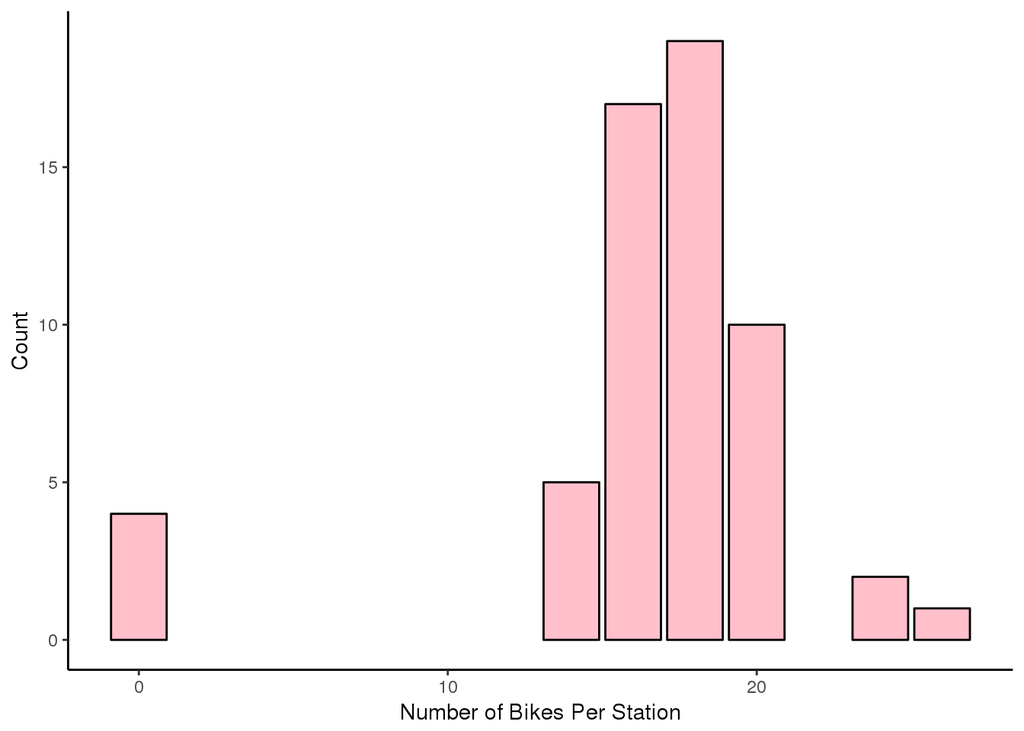

Well that’s weird, some of the stations have a dock count of 0. I’m assuming they didn’t start that way. Let’s calculate the change in dock count from station installation to August 31, 2016 and plot it on a map.

# Change in Number of Bike Docks Per Station

[figure not shown]

```r
dock_change <- station %>%
               group_by(station_id) %>%
               select(station_id, long, lat, ends_with("dockcount")) %>%
               mutate(dock_change = current_dockcount -install_dockcount)


#attempt to recreate map plot thing

closeUp <- get_map(location = "Seattle", maptype = "roadmap", zoom = 13)

ggmap(closeUp) +
  geom_point(aes(x = long, y = lat, size = factor(dock_change), color = factor(dock_change)), data = dock_change, alpha = 0.8) +
  guides(color = guide_legend(title = "change"), size = guide_legend(title = "change")) +
  scale_size_manual(values = 10:1)
```